# Machine learning

Week 7: tuning and regularization

Joshua Loftus

LSE

### Week 7: tuning and regularization

Part 1: cross-validation

Part 2: the nearest-neighbor rate

Part 3: ridge and the lasso side by side

Part 4: a penalty on wiggliness

Part 5: double descent

## Where we left off

Five functional structures, each with a knob: $\lambda$, $J$, depth, $M$, and $k$ for nearest neighbors. Each knob was chosen on the selection set, and the test set opened once

This week: how much flexibility should we allow?

- cross-validation chooses the knob
- the nearest-neighbor rate: how the error depends on $n$ and $p$
- ridge and the lasso, one coefficient at a time

### Part 1: cross-validation

## Cross-validation

We chose the knob on the selection set, $D'$: fit $\hat f_\lambda$ on $D$ for a grid of $\lambda$, score each on $D'$, keep the best, refit on $D \cup D'$. *Common when one fit is expensive*

*When one fit is cheap:*

**Idea**: swap $D$ and $D'$ and get two estimates, $\hat R(\hat f_\lambda)$ and $\hat R(\hat f'_\lambda)$. Average these and choose $\hat\lambda$ using the average

**Idea**: apply the same process with several “folds” of data

#### $K$-fold cross-validation

Each subset used once as the held-out set, and $K - 1$ times for training

## Cross-validation cartoon

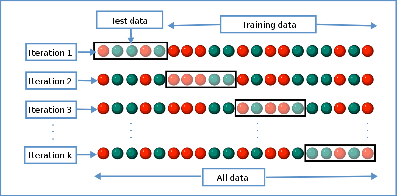

Gives $K$ estimates of the held-out error at each $\lambda$. Credit: [Wikipedia](https://en.wikipedia.org/wiki/Cross-validation)

## $K$-fold cross-validation

Each subset used once as the held-out set, and $K - 1$ times for training

Choose $\hat\lambda$ to minimize
$$\hat R_{K\text{-cv}}(\lambda) = \frac1K\sum_{k=1}^K \hat R_k\big(\hat f^{(k)}_\lambda\big)$$
where $\hat f^{(k)}_\lambda$ is fitted on the data that “holds out” the $k$th fold, and $\hat R_k$ is its error on that fold

Then refit the model $\hat f_{\hat\lambda}$ at that value $\hat\lambda$ on the entire dataset

## The CV curve on the Spotify tracks

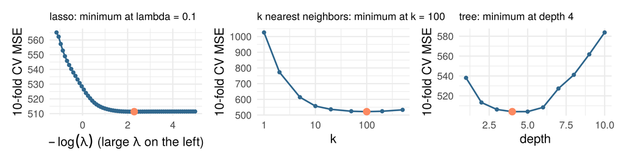

The 5,000 training tracks, $K = 10$. One curve per family, the knob where each is lowest (orange). Every fold’s fit standardizes on its own training rows. The selection set was not used: each track was fitted on nine times and scored once

## Standard errors: held out, and the CV bars

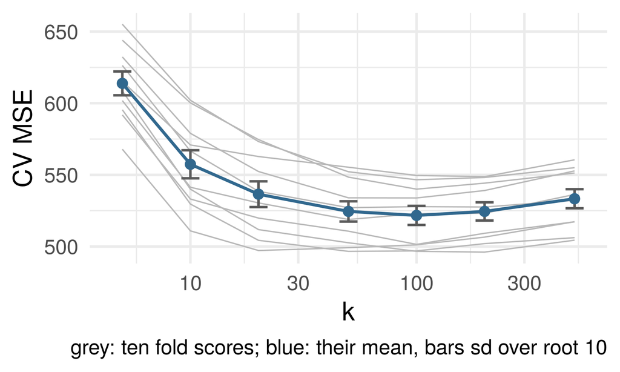

A flat bottom: $k = 50$ to $200$ are within one bar of each other

A held-out score is a mean of $m$ losses $L_j = \ell(y_j, \hat f(x_j))$, independent with $\hat f$ fixed:
$$\widehat{\text{Err}} = \frac1m\sum_{j=1}^m L_j, \qquad \text{SE} = \frac{\text{sd}(L)}{\sqrt m}$$
The structures lecture’s bars: $m = 2{,}000$ selection tracks. Software’s CV bars: the same formula on the $K$ fold scores, $m = K$; a heuristic, since the folds share fitting rows

## Lessons about cross-validation

- Think of it as a way to **choose model complexity**, not the model itself
- **Beware** common cross-validation errors! From Duda and Hart quoted in [MLstory](https://mlstory.org/data.html)

> … the same data were often used for designing and testing the classifier. This mistake is frequently referred to as “testing on the training data.” A related but less obvious problem arises *when a classifier undergoes a long series of refinements guided by the results of repeated testing on the same data. This form of “**training on the testing data**” often escapes attention until new test samples are obtained*.

## Lessons about cross-validation

- **Beware** common cross-validation errors! From ESL:

> Ideally, the test set should be kept in a “vault,” and be brought out only at the end of the data analysis. *Suppose instead that we use the test-set repeatedly, choosing the model with smallest test-set error. Then the test set error of the final chosen model will underestimate the true test error*, sometimes substantially.
- Cross-validate the entire model-building pipeline (not just one step), and only do it once – or at *least* not many times
- Choosing $K$: larger $\to$ $\hat R_{K\text{-cv}}$ has lower bias, more variance. Often use $K = 5$ or $10$

## plot(cv.glmnet)

`glmnet`’s own cross-validation of the lasso on the training tracks, the same ten folds. Top axis: how many coefficients are nonzero

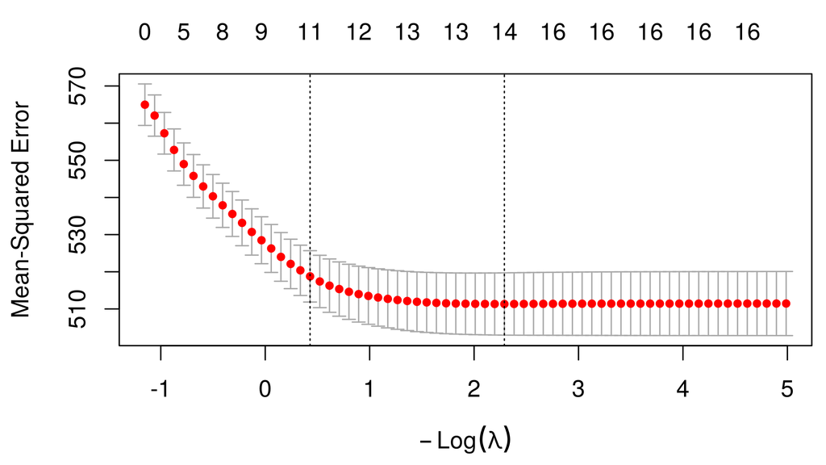

```r
cv_fit <- cv.glmnet(X, y, foldid = fold)
plot(cv_fit)
```

Dotted lines: `lambda.min`, the minimum; `lambda.1se`, the largest $\lambda$ within one bar of it, the **one-standard-error rule**

The bars, $\text{sd}/\sqrt K$ of the fold scores, are a heuristic (the folds share rows). The minimum is chosen among 67 candidates on these rows: biased low, a score to choose with, not to report

### Part 2: the nearest-neighbor rate

## Why care about rates?

Over a trillion dollars is going into scaling up AI models. What if this is mathematically guaranteed to fail?

[Data Centers Are Burning Fossil Fuels. It’s Destroying Big Tech’s Climate Goals](https://www.cnet.com/tech/services-and-software/data-centers-ai-climate-change-hyperscale/)

## The best $k$ as $n$ and $p$ grow

The CV curve put $k$ at 100 on 5,000 tracks and $p = 11$ inputs. Where would the minimum be with 50,000 tracks? With 110 inputs?

Bias–variance decomposition, $k$-NN form: inputs fixed, $y_i = f^\star(x_i) + \varepsilon_i$, $\varepsilon_i$ independent, mean $0$, variance $\sigma^2$; $\hat f_k(x_0)$ the mean of the $k$ nearest $y_i$:
$$\mathbb E\big[(Y_0 - \hat f_k(x_0))^2\big] = \sigma^2 + \Big[f^\star(x_0) - \tfrac1k\textstyle\sum_l f^\star(x_{(l)})\Big]^2 + \sigma^2/k$$

The variance term is explicit, $\sigma^2/k$. The bias term depends on $f^\star$ at the $k$ nearest inputs, and can be bounded only by an assumption on $f^\star$

What assumption on $f^\star$ makes the bias term a number? Write it down.

## $k$-NN rate: bounding the bias

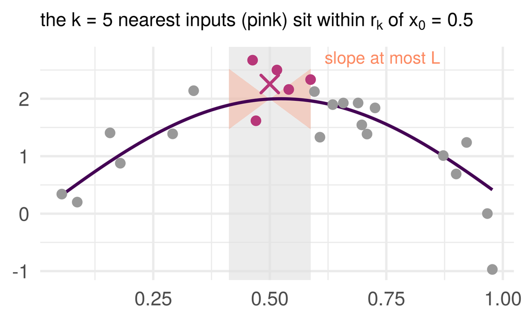

$r_k(x_0)$: the distance from $x_0$ to its $k$th nearest training input. Every neighbor is within it

**Assume** $f^\star$ is $L$-**Lipschitz**: $|f^\star(x) - f^\star(x')| \le L\,\|x - x'\|$. Then each neighbor’s $f^\star$ is within $L\,r_k$ of $f^\star(x_0)$, so their average is too

**$k$-NN rate.** Inputs fixed, $f^\star$ $L$-Lipschitz, noise variance $\sigma^2$: $\;\mathbb E\big[(\hat f_k(x_0) - f^\star(x_0))^2 \,\big|\, \text{inputs}\big] \;\le\; L^2\, r_k(x_0)^2 + \sigma^2/k$

**Proof.** “Inputs fixed”: given the training inputs $x_1, \ldots, x_n$, the neighbors are fixed and only the noise is random. The bias $\frac1k\sum_l [f^\star(x_{(l)}) - f^\star(x_0)]$ has each term at most $L\,r_k$ in size, so its square is at most $L^2 r_k^2$; the variance is $\sigma^2/k$. $\blacksquare$

## The nearest-neighbor distance lemma

How far away is the $k$th neighbor? Inputs i.i.d. uniform on $[0, 1]^p$. A ball around $x_0$ holding $k$ of the $n$ points has volume about $k/n$, so its radius is about $(k/n)^{1/p}$

**Nearest-neighbor distance lemma** (stated). For $x_0$ away from the boundary, $\mathbb E\big[r_k(x_0)^2\big] \le C_p\,(k/n)^{2/p}$, with $C_p$ depending on $p$ only.

In one dimension the $k$th neighbor is about $k/2n$ away on each side. In $p = 10$ the radius is about $(k/n)^{1/10}$: with $k/n = 1/100$, $0.63$ of the side of the cube

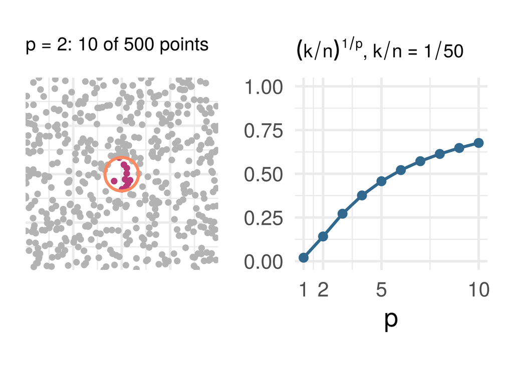

Curse of dimensionality: in many dimensions, the nearest $1\%$ of the data is not near.

## The rate

Put the two together and choose $k$:
$$\mathbb E\big[(\hat f_k(x_0) - f^\star(x_0))^2\big] \;\le\; C_p L^2 (k/n)^{2/p} + \sigma^2/k$$
The first term grows with $k$, the second shrinks. They balance at $k = c\,n^{2/(p+2)}$, and there
$$\text{error} \le C\, n^{-2/(p+2)}, \qquad c, C \text{ constants not depending on } n$$

To halve the bound, $2^{(p+2)/2}$ times the data: $2.8\times$ in $p = 1$, $4\times$ in $p = 2$, $64\times$ in $p = 10$

**Minimax rate** (stated). Over all $L$-Lipschitz $f^\star$ in $p$ dimensions no estimator beats $n^{-2/(p+2)}$ for every $f^\star$ (Stone 1980, 1982); a particular $f^\star$, a constant say, does better.

## The cost of a non-free lunch

| Assumption on $f^\star$ | Squared error (up to constants; rows 1 and 2 minimax) | The family |
| --- | --- | --- |
| $L$-Lipschitz in $p$ inputs | $n^{-2/(p+2)}$ | nearest neighbors, a tree, a network: smoothness only |
| a sum of a fixed number of Lipschitz one-input curves (additivity, plus design conditions) | $n^{-2/3}$, the one-input rate (Stone 1985) | additive splines: no interactions |
| linear with $s$ nonzero coefficients among $p$ (sparsity, plus design and noise conditions) | about $s\log p/n$, an upper bound (Hastie et al. 2015, Theorem 11.2) | the lasso: a sparse plane |

Smoothness alone: $p$ in the exponent. Additivity: the one-input exponent. Sparsity: $p$ out of the exponent, into a $\log p$. Rows 2 and 3 are stated, not derived

No free lunch theorem, with numbers. A faster rate needs a stronger assumption.

### Part 3: ridge and the lasso side by side

Assumptions $\leftrightarrow$ biases?

## History: Stein’s paradox

Estimating $\mu \in \mathbb R^p$ from an i.i.d. sample $\mathbf Y_1, \ldots, \mathbf Y_n \sim N(\mu, \sigma^2 I)$. The MLE is $\bar{\mathbf Y}$ (obvious and best, right?)

[Charles Stein](https://news.stanford.edu/2016/12/01/charles-m-stein-extraordinary-statistician-anti-war-activist-dies-96/) discovered in the 1950’s that the MLE is *[inadmissible](https://en.wikipedia.org/wiki/Admissible_decision_rule)* if $p > 2$ 🤯

The [James–Stein estimator](https://en.wikipedia.org/wiki/Stein%27s_example) **shrinks** $\bar{\mathbf Y}$ toward some other point, any other point, chosen *a priori*, e.g. 0:
$$\hat\mu_{\text{JS}} = \Big(1 - \frac{(p-2)\sigma^2/n}{\|\bar{\mathbf Y}\|^2}\Big)\bar{\mathbf Y}, \qquad \text{MSE}(\hat\mu_{\text{JS}}) < \text{MSE}(\bar{\mathbf Y}) \text{ for all } \mu, \text{ if } p > 2$$

## Shrinkage: less variance, more bias

[James–Stein shrinkage demo](https://ml4ds.com/weeks/07-regularization-highdim/james-stein.html)

Statisticians emphasized unbiasedness. After Stein’s example, bias is not always bad. Most ML methods use bias this way

## Ridge and the lasso, again

$$\text{ridge: } \min_\beta\ \|\mathbf y - \mathbf X\beta\|_2^2 + \lambda\|\beta\|_2^2$$
$$\|\beta\|_2^2 = \sum_{j=1}^p \beta_j^2$$

$$\text{lasso: } \min_\beta\ \|\mathbf y - \mathbf X\beta\|_2^2 + \lambda\|\beta\|_1$$
$$\|\beta\|_1 = \sum_{j=1}^p |\beta_j|$$

Ridge’s estimates are dense: every coefficient nonzero, in general; the lasso’s are exactly zero over whole ranges of $\lambda$. What $\lambda$ does to one coefficient is hidden in general, because the coefficients interact; in the simplest design they do not

## The identity design

$\mathbf X = I$ ($n = p$), so $\mathbf y = \beta + \boldsymbol\varepsilon$: one observation per coefficient, least squares $\hat\beta = \mathbf y$. A penalty that adds up over coefficients, as ridge’s and the lasso’s do, splits the objective: $\|\mathbf y - \beta\|_2^2 + \mathcal P_\lambda(\beta) = \sum_j \big[(y_j - \beta_j)^2 + \mathcal P_\lambda(\beta_j)\big]$, one problem per coefficient

**Ridge**: $\hat\beta_{\lambda, j} = \dfrac{y_j}{1 + \lambda}$, every coefficient shrunk by the same factor, zero only if $y_j = 0$

**Lasso**: $\hat\beta_{\lambda, j} = \mathrm{sign}(y_j)\,\big(|y_j| - \tfrac{\lambda}{2}\big)_+$, each $y_j$ moved toward zero by $\lambda/2$, stopping at zero: exactly zero whenever $|y_j| \le \lambda/2$

**Soft thresholding.** $\arg\min_b\ (y - b)^2 + \lambda|b| = \mathrm{sign}(y)\,(|y| - \lambda/2)_+$. Deriving both minimizers: an exercise in the notebook.

## Bias–variance decomposition, ridge form

Same design, noise variance $\sigma^2$. Least squares, $\hat\beta = \mathbf y$: unbiased, variance $\sigma^2$ per coefficient. Divide by $1 + \lambda$:
$$\text{bias}_j = -\frac{\lambda}{1 + \lambda}\,\beta_j, \qquad \mathrm{Var}(\hat\beta_{\lambda,j}) = \frac{\sigma^2}{(1 + \lambda)^2}$$

**Bias–variance decomposition, ridge form.** $\mathbf X = I$, $\mathbf y = \beta + \boldsymbol\varepsilon$, noise independent, mean $0$, variance $\sigma^2 > 0$: $\;\mathrm{MSE}(\lambda) = \mathbb E\|\hat\beta_\lambda - \beta\|^2 = \sum_{j=1}^p (\lambda^2\beta_j^2 + \sigma^2)/(1 + \lambda)^2$, with slope $-2p\sigma^2 < 0$ at $\lambda = 0$: for every $\beta$, some $\lambda > 0$ beats least squares.

**Proof**: an exercise in the notebook. Which $\lambda$? The best is $\sigma^2$ over the mean of $\beta_j^2$, noise over signal: unknown

## High-dimensional example

$n = 100$ observations, $p = 200$ inputs, $\mathbf y = \mathbf X\beta + \boldsymbol\varepsilon$ with only 16 nonzero coefficients. Lasso and ridge at the $\lambda$ cross-validation chooses

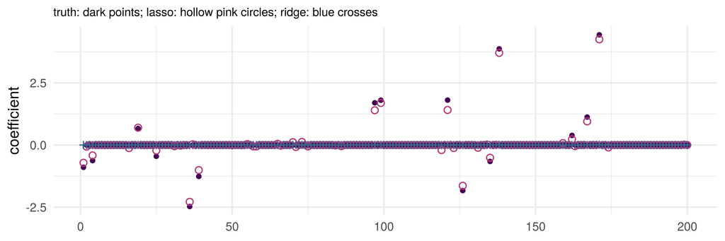

## Zoom in on variables 50 to 100

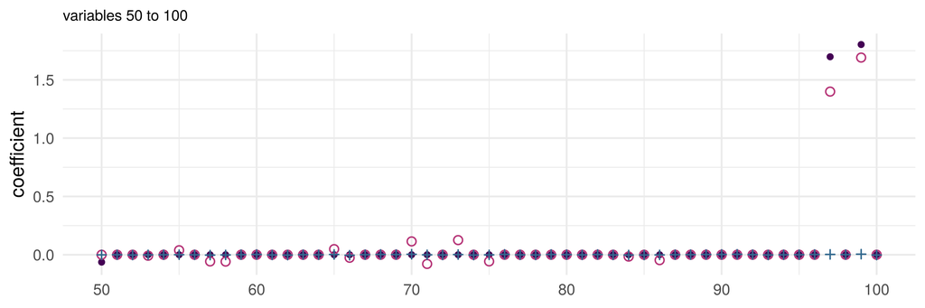

## Lasso: cool or extremely cool?

Penalized regression biases coefficients toward zero

The lasso usually sets some of them **all the way to zero**, so it does variable selection as it fits

People like sparser, simpler models: they can be easier to interpret

## Lasso downside: instability

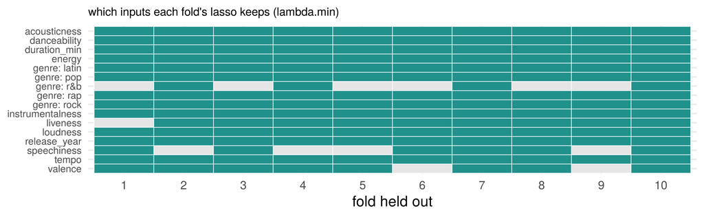

The ten models cross-validation fit, each on nine folds, at `lambda.min`: the kept inputs change from fold to fold. The same instability as a tree’s cutoffs. At the one-SE $\lambda$ the ten sets agree

## A fixed $\lambda$ and a data-chosen $\hat\lambda$

$\hat\beta_{\text{lasso}}(\lambda)$ at a fixed $\lambda$

$\hat\beta_{\text{lasso}}(\hat\lambda)$ at a data-chosen $\hat\lambda$

Different in general! Theoretical results about the first (the rate, the ridge-form decomposition at a fixed $\lambda$) may not apply to the second

Choosing on a dataset is empirical risk minimization over a finite class: the winner’s score on the rows it was chosen on is biased low.

### Part 4: a penalty on wiggliness

## A penalty on wiggliness

The spline of the structures lecture: $f(x) = \beta_0 + \sum_{j=1}^J \beta_j b_j(x)$, $J$ the knob. Instead: take a large $J$ as a ceiling, and penalize **wiggliness**

$$\min_f\; \textstyle\sum_{i=1}^n \big(y_i - f(x_i)\big)^2 + \lambda\int f''(x)^2\,dx$$
$\lambda = 0$: the $J$-basis fit. $\lambda \to \infty$: $f'' = 0$, a straight line. In between: $\lambda$ chosen by generalized cross-validation (GCV, `mgcv`’s default)

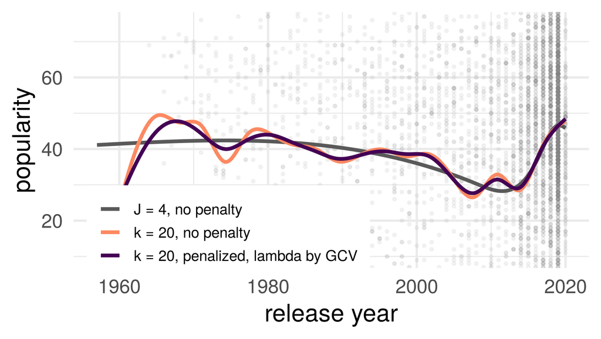

```r
library(mgcv)
gam(track_popularity ~ s(release_year, k = 20, bs = "cr"), data = sp_train)
```

## The smoothing penalty as weighted ridge

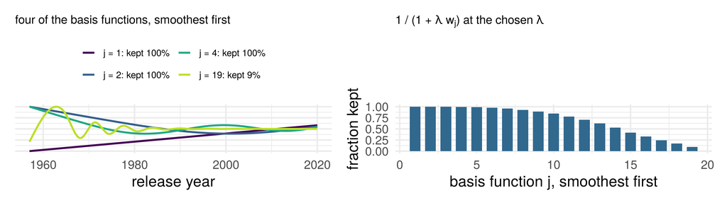

In the right basis, coefficient $j$ is shrunk by $1/(1 + \lambda w_j)$, $w_j$ the wiggliness of basis function $j$. The straight line ($w = 0$) is never shrunk; the wiggles nearly vanish. Ridge’s formula, with a weight

### Part 5: double descent

## The bias–variance trade-off

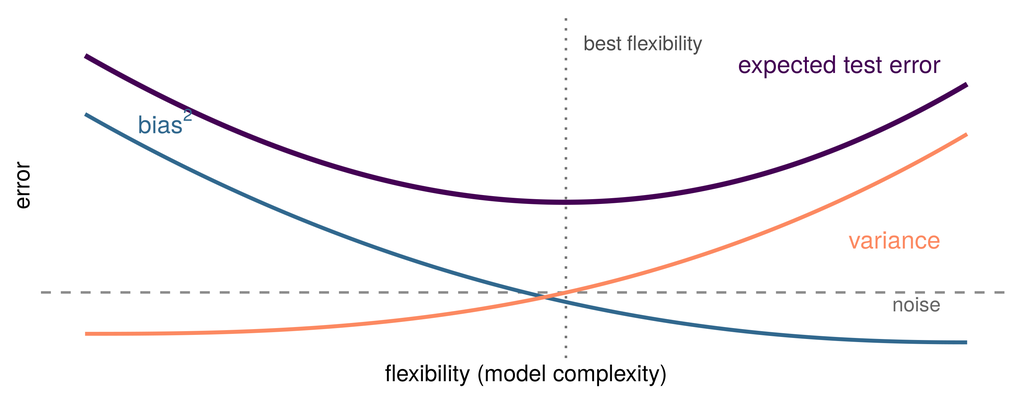

Expected test error = noise + bias$^2$ + variance. More flexibility: less bias, more variance; the sum is a U

## Does statistics apply to deep learning?

The bias–variance trade-off is one of the most important pillars of statistical wisdom. If we make a model too complex, it overfits to the training data… or does it?

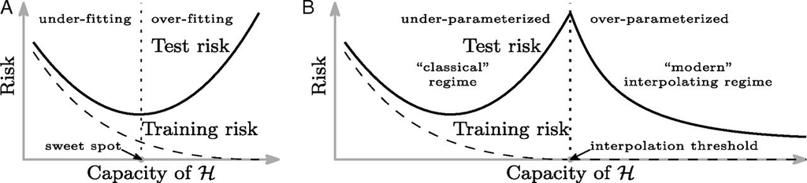

Belkin, Hsu, Ma and Mandal (2019). Does zero training error *necessarily* mean the model is overfit? **No.**

## Zero training error: what does it mean?

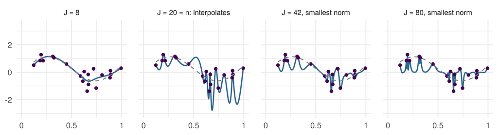

$n = 20$ points, natural splines with $J$ basis functions: least squares up to $J = n$; beyond, of the many fits with zero training error, the one with the smallest $\|\beta\|$ (ridge’s limit as $\lambda \to 0$). Zero training error does not say which fit you have

## Double descent, demonstrated

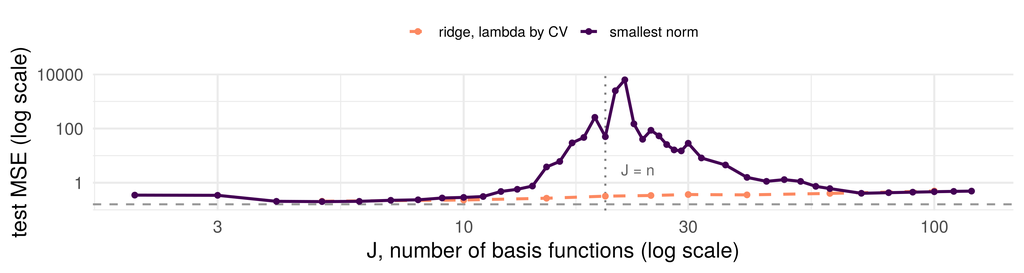

Test MSE against $J$, averaged over 50 draws of 20 points: a U up to $J = n$, a spike at $J = n$ (interpolation threshold), a second descent beyond it (Belkin, Hsu, Ma and Mandal 2019). Ridge on same basis, $\lambda$ by cross-validation: never interpolates, no spike. Dashed: noise variance

## Double descent: takeaways

**It can happen** for some models (large neural networks) on some data (high signal-to-noise: images, translation). So zero training error does not necessarily mean overfit, and a test error that has started rising might fall again later: we don’t know

**It does not contradict the bias–variance trade-off.** The horizontal axis may not accurately indicate model complexity

**For most methods in this course, expect a U**: $k$-NN, trees, ridge, the lasso. Regularized fits do not interpolate, and have no second descent (the ridge curve)

ISLR section 10.8, pp. 441–443

## Before the seminar

- This week: exercises 1 and 2 at the top of the notebook. The ridge form of the bias–variance decomposition, proved in the orthogonal design with numbered hints; and the $k$-NN rate again, with the slides closed
- In the seminar: a cross-validation pipeline on the Spotify tracks, written as one function and run for $k$-NN and the lasso; a learning-curve figure to read against the rate; and then, after it has worked, three ways cross-validation goes wrong

## Conclusion

- Cross-validation: the standard for tuning when model fits are less expensive and/or datasets aren’t extremely large. The minimum CV-error underestimates risk of the chosen model
- Modeling assumptions (smoothness, additivity, sparsity, wiggliness) make different types of models work well. We generally don’t know if assumptions are true
- Most ML models are optimized (in the bias–variance trade-off) with nonzero bias. Achieving zero training error without overfitting is not a new discovery of the AI community and does not contradict the trade-off

## References

- Belkin, M., Hsu, D., Ma, S. and Mandal, S. (2019). Reconciling modern machine-learning practice and the classical bias–variance trade-off. *Proceedings of the National Academy of Sciences* 116(32), 15849–15854. [doi:10.1073/pnas.1903070116](https://doi.org/10.1073/pnas.1903070116)
- Hastie, T., Tibshirani, R. and Friedman, J. (2009). *The Elements of Statistical Learning: Data Mining, Inference, and Prediction*, 2nd edition. Springer, New York. Section 7.2, p. 222 (the quotation). [hastie.su.domains/ElemStatLearn](https://hastie.su.domains/ElemStatLearn/)
- Hastie, T., Tibshirani, R. and Wainwright, M. (2015). *Statistical Learning with Sparsity: The Lasso and Generalizations*. Chapman and Hall/CRC. Theorem 11.2(b), equation (11.26b), p. 300 (prediction error); Theorem 11.1 and Example 11.1, pp. 295–296 (coefficient error). [doi:10.1201/b18401](https://doi.org/10.1201/b18401); free PDF at [hastie.su.domains/StatLearnSparsity](https://hastie.su.domains/StatLearnSparsity/)

## References, continued

- James, G., Witten, D., Hastie, T. and Tibshirani, R. (2021). *An Introduction to Statistical Learning with Applications in R*, 2nd edition. Springer, New York. Section 10.8 and Figure 10.21, pp. 439–443 (the zero-error fits, adapted). statlearning.com
- Stone, C. J. (1980). Optimal rates of convergence for nonparametric estimators. *Annals of Statistics* 8(6), 1348–1360. [doi:10.1214/aos/1176345206](https://doi.org/10.1214/aos/1176345206)
- Stone, C. J. (1982). Optimal global rates of convergence for nonparametric regression. *Annals of Statistics* 10(4), 1040–1053. [doi:10.1214/aos/1176345969](https://doi.org/10.1214/aos/1176345969)
- Stone, C. J. (1985). Additive regression and other nonparametric models. *Annals of Statistics* 13(2), 689–705. [doi:10.1214/aos/1176349548](https://doi.org/10.1214/aos/1176349548)